# Dimension Reduction

Rafael Irizarry

### Motivation

*Visualizing data is one of the most task of data science.

- Visualization may reveal problems with data that can render the results from a standard analysis completely useless.
- It can also help us make us important discoveries.
- How do we visualize high dimensional data
- To visualize 784 features we need 306,936 scatter plots.
- Principal Component Analysis (PCA)

### Example: Reducing two dimensions to one

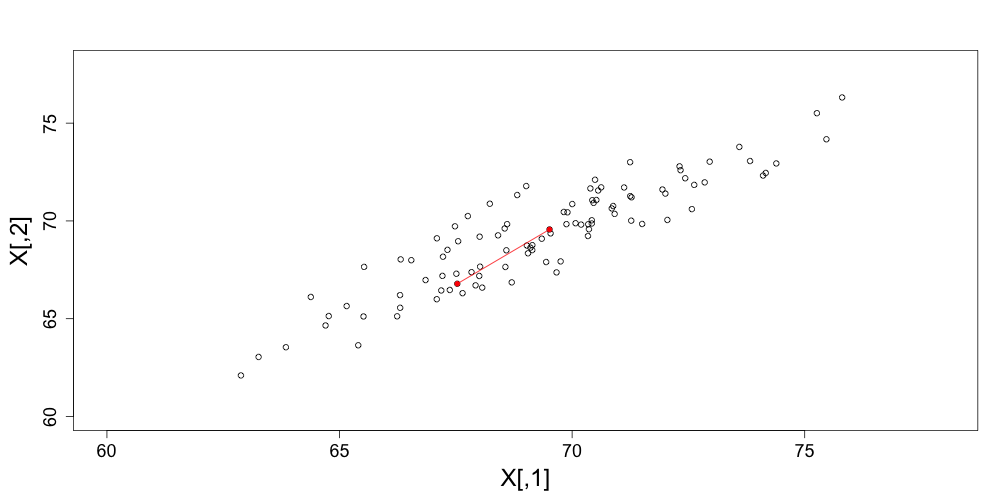

### We Want to Preserve Distance

```r
d=dist(X)
as.matrix(d)[1,2]
```

```
[1] 3.41
```

### Matrices in R

### Assessment

If I center the data by removing the average from both columns, does the distance between pairs of twins change?

### Center the Data

```r
X <- sweep(X, 2, colMeans(X))

## or

X <- t(t(X) - rowMeans(t(X)))
```

Can we reduce to one dimension?

### Naive approach

Consider just the first dimension

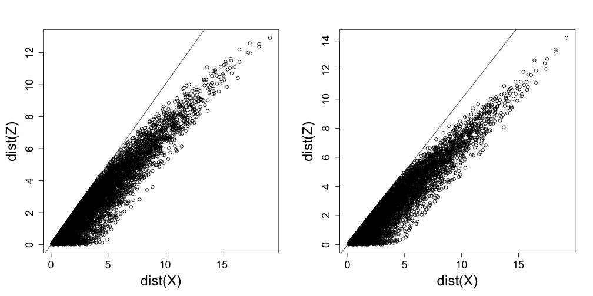

### Scaling the Distance

The actual distance is generally underestimated.

If we instead us this definition of distance:

\[ \sqrt{ \frac{1}{2} \sum_{j=1}^2 (X_{i,j}-X_{i,j})^2 } \]

### Scaling the Distance

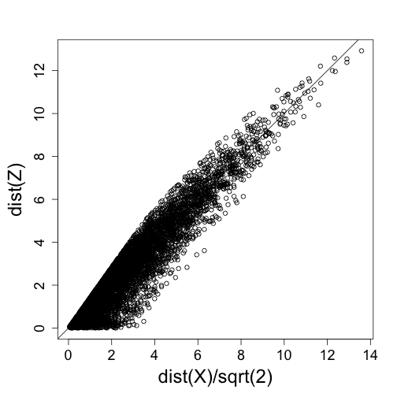

### Can we improve?

```r
cor(dist(X), dist(Z))
```

```
[1] 0.947
```

### Rotations

We wil consider the following transformation:

```r
avg <- rowMeans(X) ##same as (X[,1] + X[,2])/2
diff <- X[,2] - X[,1]

Z  <- cbind( avg, diff)
```

### Rotation

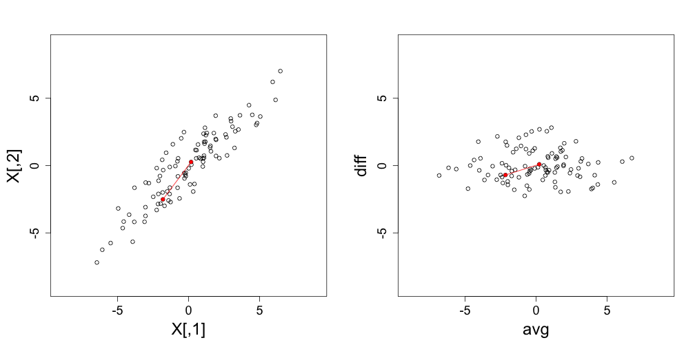

### Just the first dimension

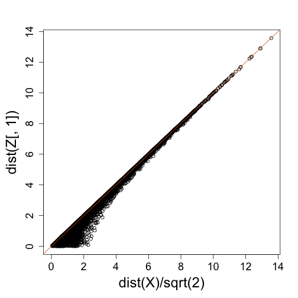

```
correlation =  0.993
```

### Linear Transformation

\[ Z_{i,1} = a_{1,1} X_{i,1} + a_{2,1} X_{i,2} \]

with \( a_{1,1} = 0.5 \) and \( a_{2,1} = 0.5 \)

The second entry was also a linear transformation

\[ Z_{i,2} = a_{1,2} X_{i,1} + a_{2,2} X_{i,2} \]

with \( a_{1,2} = 1 \) and \( a_{2,2} = -1 \)

### Rotating Back

We can also use linear transformation to get \( X \) back from \( Z \):

\[ X_{i,1} = b_{1,1} Z_{i,1} + b_{2,1} Z_{i,2} \]

with \( b_{1,2} = 1 \) and \( b_{2,1} = 0.5 \) and

\[ X_{i,2} = b_{2,1} Z_{i,1} + b_{2,2} Z_{i,2} \]

with \( b_{2,1} = 1 \) and \( a_{1,2} = -0.5 \)

### Linear Algebra

If you are familiar with linear algebra:

\[ Z = Y A \mbox{ with } A = \, \begin{pmatrix} 1/2&1\\ 1/2&-1\\ \end{pmatrix} \]

Transform back by simply multiplying by \( A^{-1} \) as follows:

\[ Y = Z A^{-1} \mbox{ with } A^{-1} = \, \begin{pmatrix} 1&1\\ 1/2&-1/2\\ \end{pmatrix} \]

### Orthogogal transformations

We can actually guarantee that the distance scales remain the same by picking *orthogonal* linear transformation:

Sum of squares of columns is 1

\[ a_{1,1}^2 + a_{2,1}^2 = 1\mbox{ and } a_{1,2}^2 + a_{2,2}^2=1 \]

Correlation of different columns is 0: \[ a_{1,1} a_{1,2} + a_{2,1} a_{2,2} = 0 \]

### Orthogogal transformations

In this example we obtain desired results with:

```r
Z[,1] <- (X[,1] + X[,2])/sqrt(2)
Z[,2] <- (X[,2] - X[,1])/sqrt(2)
```

In this case \( Z \) is called an orthogonal rotation of \( X \).

### Preserves the distances between points

And first dimension provides great approximation:

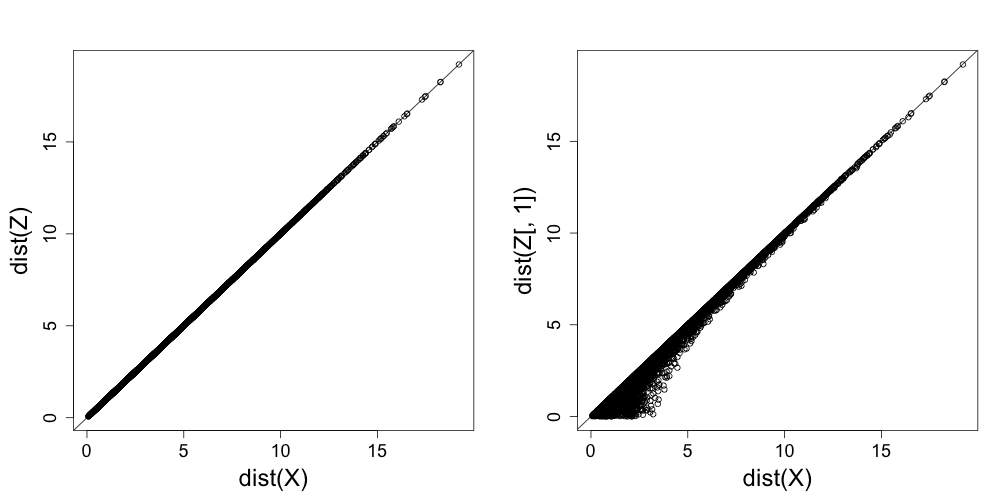

### Dimension Reduction

The reason we were able to reduce dimension was because of high correlations:

```r
cor(X[,1], X[,2])
```

```
[1] 0.91
```

The transformation produced uncorrelated columns:

```r
cor(Z[,1], Z[,2])
```

```
[1] -0.000994
```

### Principal Component Analysis (PCA)

We assume the column are centered so we have:

\[ v_1 = \frac{1}{N}\sum_{i=1}^N X_{i,1}^2 \mbox{ and } v_2 = \frac{1}{N}\sum_{i=1}^N X_{i,1}^2 \]

Which we can compute using:

```r
colMeans(X^2)
```

```
[1] 7.23 7.22
```

### Variance Explained

With orthogonal transformation the total variation remains the same:

```r
sum(colMeans(X^2))
```

```
[1] 14.5
```

```r
sum(colMeans(Z^2))
```

```
[1] 14.5
```

The variability in the columns of `X` is about the same.

### Variance Explained

```r
v <- colMeans(Z^2)
v/sum(v)
```

```
   avg   diff
0.9548 0.0452
```

### PCA

Of all orthogonal transformation, the one that maximizes variance of first column is PC1.

We can actually find this transformation mathematically:

```r
prcomp(X)
```

```
Standard deviations:
[1] 3.734 0.813

Rotation:
       PC1    PC2
[1,] 0.707  0.707
[2,] 0.707 -0.707
```

### Iris Example

We can applu these ideas to higher dimensions.

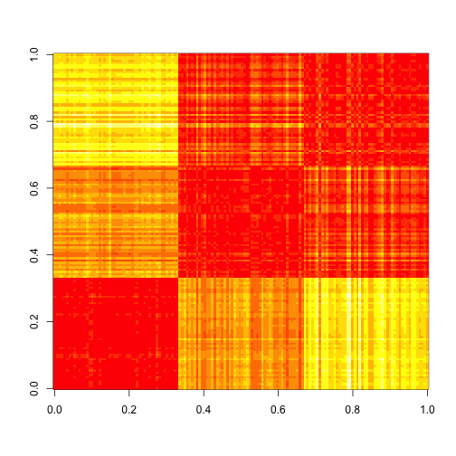

### Correlated Predictors

```r
cor(X) %>% kable
```

|  | Sepal.Length | Sepal.Width | Petal.Length | Petal.Width |
| --- | --- | --- | --- | --- |
| Sepal.Length | 1.000 | -0.118 | 0.872 | 0.818 |
| Sepal.Width | -0.118 | 1.000 | -0.428 | -0.366 |
| Petal.Length | 0.872 | -0.428 | 1.000 | 0.963 |
| Petal.Width | 0.818 | -0.366 | 0.963 | 1.000 |

### PCA

```r
pc <- prcomp(X)
summary(pc)
```

|  | PC1 | PC2 | PC3 | PC4 |
| --- | --- | --- | --- | --- |
| Standard deviation | 2.056 | 0.493 | 0.280 | 0.154 |
| Proportion of Variance | 0.925 | 0.053 | 0.017 | 0.005 |
| Cumulative Proportion | 0.925 | 0.978 | 0.995 | 1.000 |

### Excellent 2D Approximation

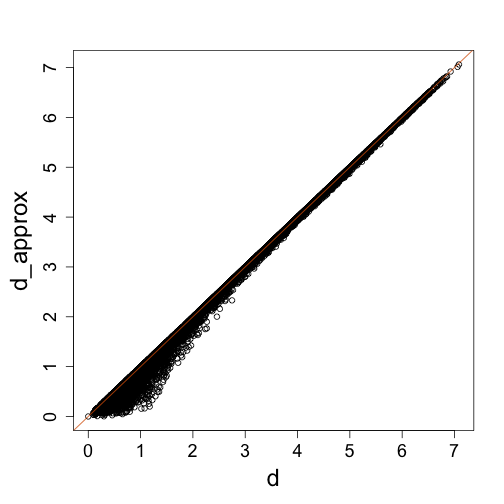

### Visualization

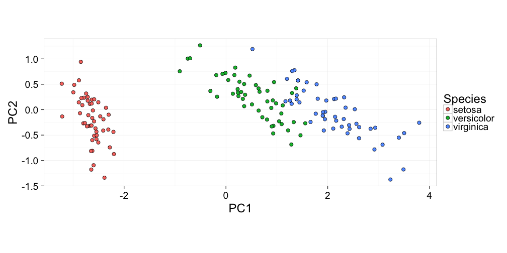

### Example from Biomedical Research

Data from [this paper](http://www.ncbi.nlm.nih.gov/pubmed/17206142)

### Variance Explained Plots

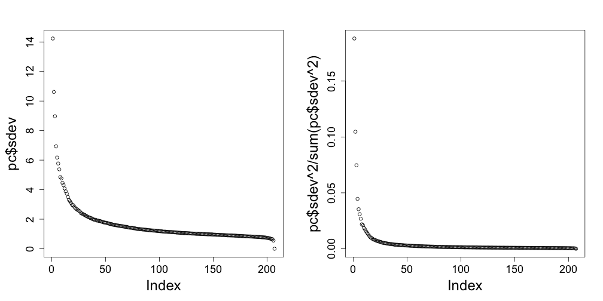

### PCA Plot

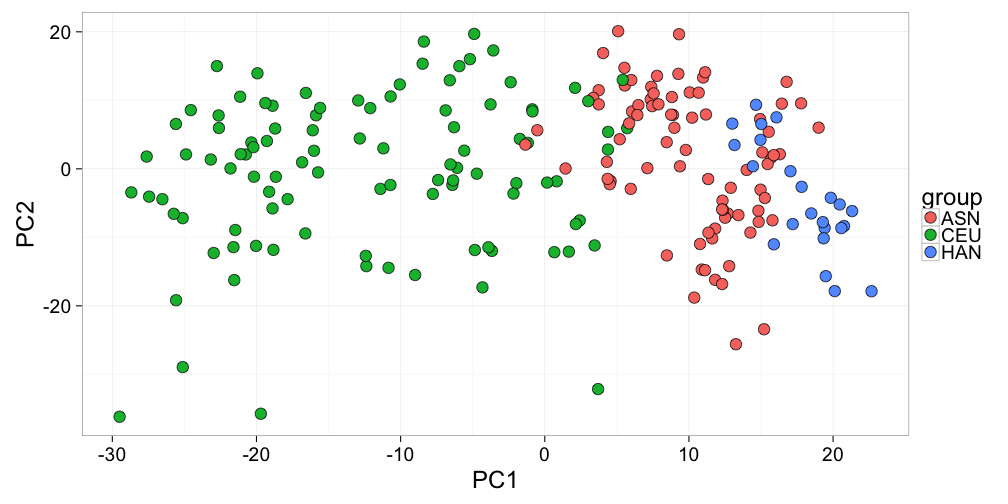

### PCA Plot

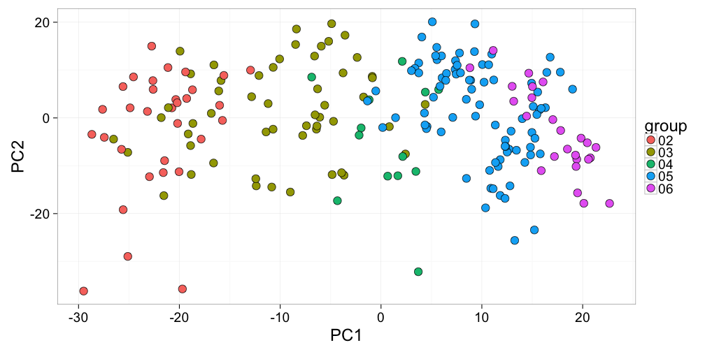

### Further Exploration

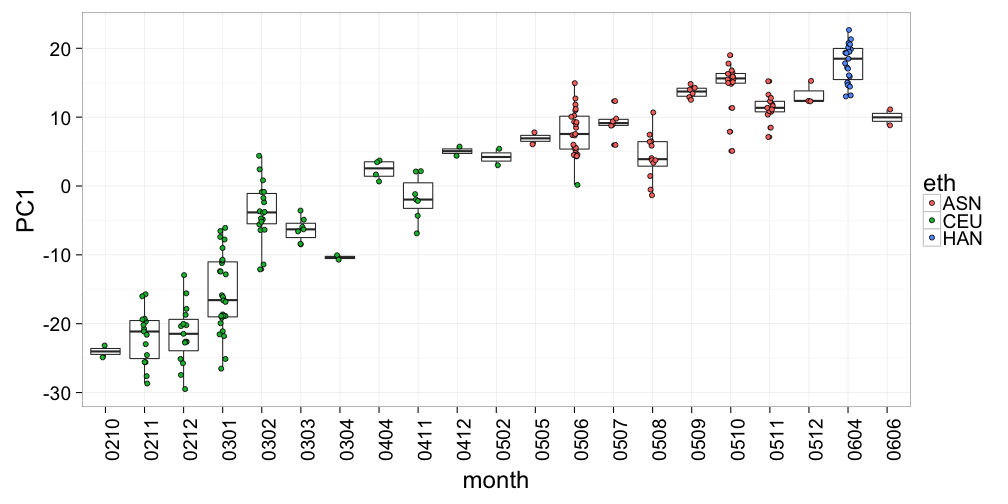

### The Written Digits

```r
library(readr)
library(dplyr)
url <- "https://raw.githubusercontent.com/datasciencelabs/data/master/hand-written-digits-train.csv"
if(!exists("digits")) digits <- read_csv(url)

library(caret)
set.seed(1)
inTrain <- createDataPartition(y = digits$label, p=0.9)
train_set <- slice(digits, inTrain$Resample1)
test_set <- slice(digits, -inTrain$Resample1)
X <- train_set %>% select(-label) %>% as.matrix()
```

### Correlation Between Features

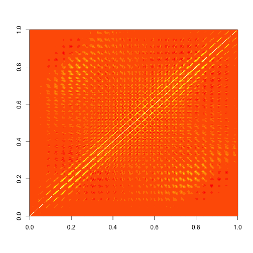

### PCA

```r
pc <- prcomp(X)
```

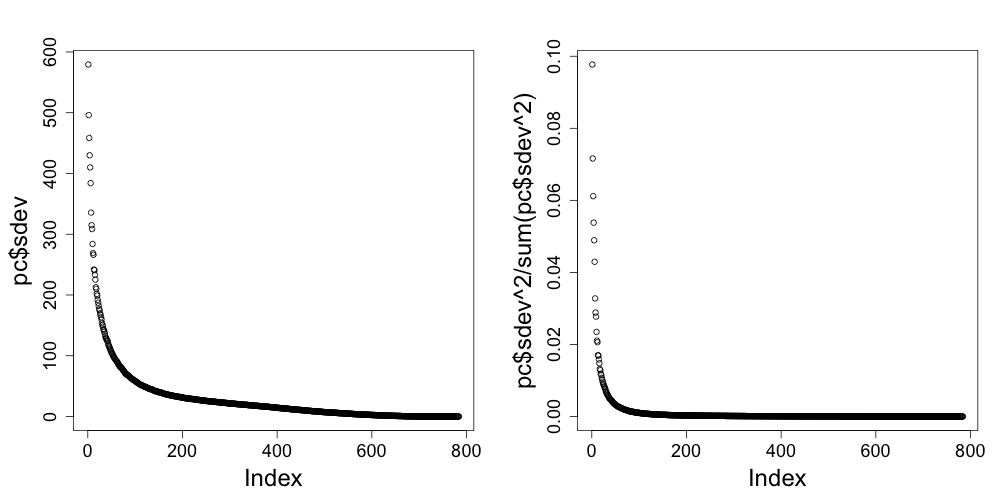

### PCA plot

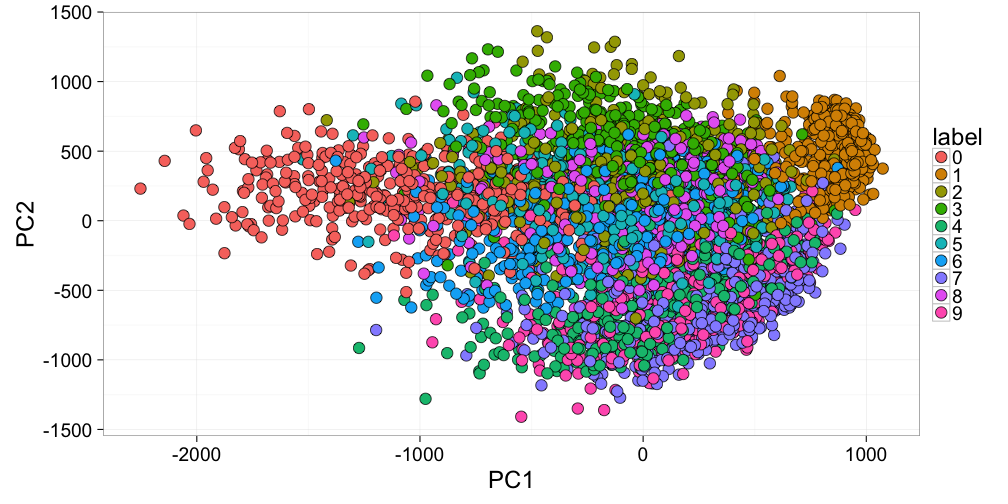

### Rotation Coefficients: PC1 to PC4

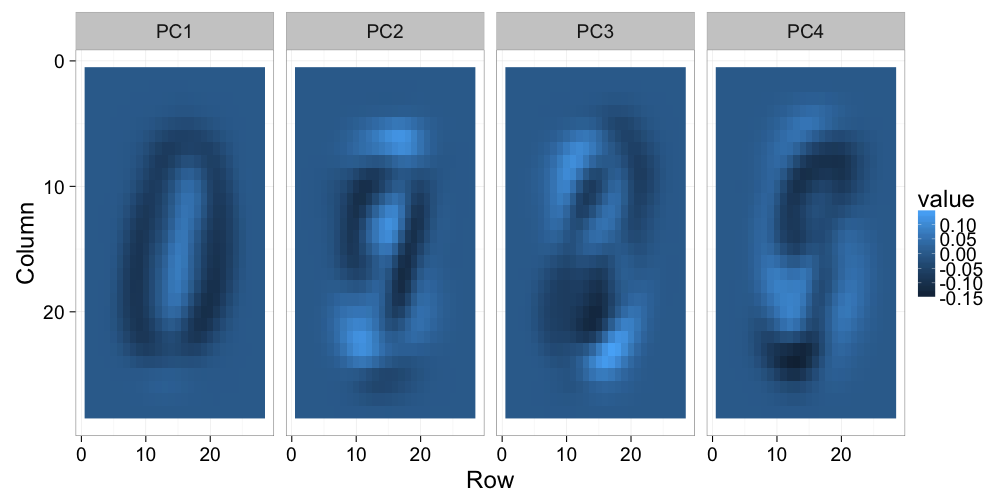

### Rotation Coefficients: PC781 to PC784

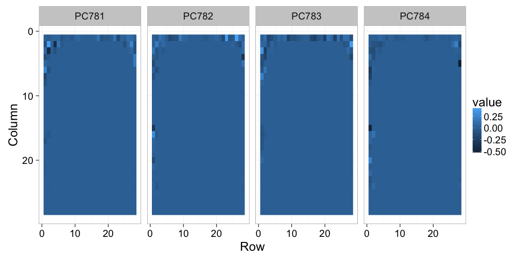

### Machine Learning Application

```r
library(caret)
y <- factor(train_set$label)
K <- 36
x <- pc$x[,1:K]
fit <- knn3(x, y, k=5)
X_test <- test_set %>% select(-label) %>% as.matrix()
pc_test <- predict(pc, X_test)
pred <- predict(fit,
                newdata=data.frame(x = pc_test[,1:K]),
                type="class")
confusionMatrix(pred, test_set$label)$overall[1]
```

[output not shown]